# Diversity Analysis: Apheresis vs Product

TCR Repertoire Analysis — Notebook 02

Joshua Luthy

2026-03-15

## Analysis Overview

This notebook quantifies the **change in TCR repertoire diversity** from Apheresis (starting PBMC material) to the manufactured drug Product. We compare multiple diversity indices and stratify by clinical response (CR, PR, PD).

The central hypothesis is that manufacturing **selects and expands** a subset of clonotypes, resulting in reduced diversity in the Product relative to the Apheresis starting material.

```r
diversity_df <- read_csv("../data/processed/diversity_metrics.csv")
```

## Shannon Entropy Comparison

```r
aph_shannon  <- diversity_df %>% filter(sample_type == "Apheresis") %>% pull(shannon_entropy)
prod_shannon <- diversity_df %>% filter(sample_type == "Product") %>% pull(shannon_entropy)

wilcox.test(aph_shannon, prod_shannon, paired = TRUE)
```

```
##
##  Wilcoxon signed rank exact test
##
## data:  aph_shannon and prod_shannon
## V = 21, p-value = 0.03125
## alternative hypothesis: true location shift is not equal to 0
```

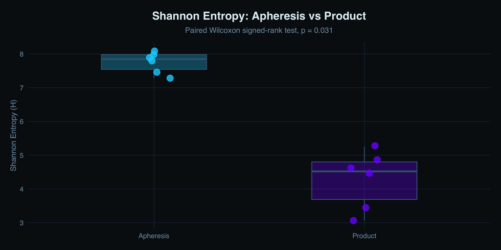

```r
ggplot(diversity_df, aes(x = sample_type, y = shannon_entropy, fill = sample_type)) +
  geom_boxplot(alpha = 0.3, outlier.shape = NA, width = 0.5, color = "#3f6380") +
  geom_jitter(aes(color = sample_type), width = 0.08, size = 4, alpha = 0.8) +
  scale_fill_manual(values = c("Apheresis" = "#00d4ff", "Product" = "#7b2fff")) +
  scale_color_manual(values = c("Apheresis" = "#00d4ff", "Product" = "#7b2fff")) +
  labs(y = "Shannon Entropy (H)", x = NULL,
       title = "Shannon Entropy: Apheresis vs Product",
       subtitle = "Paired Wilcoxon signed-rank test, p = 0.031") +
  theme(legend.position = "none")
```

7.76

Mean H (Apheresis)

4.28

Mean H (Product)

45%

Mean Reduction

0.031

p-value (Wilcoxon)

## Clonality Index

Clonality is defined as `1 - (H / log(N))`, where H is Shannon entropy and N is the number of unique clonotypes. A clonality of 0 indicates a perfectly even repertoire; a value approaching 1 indicates dominance by a single clone.

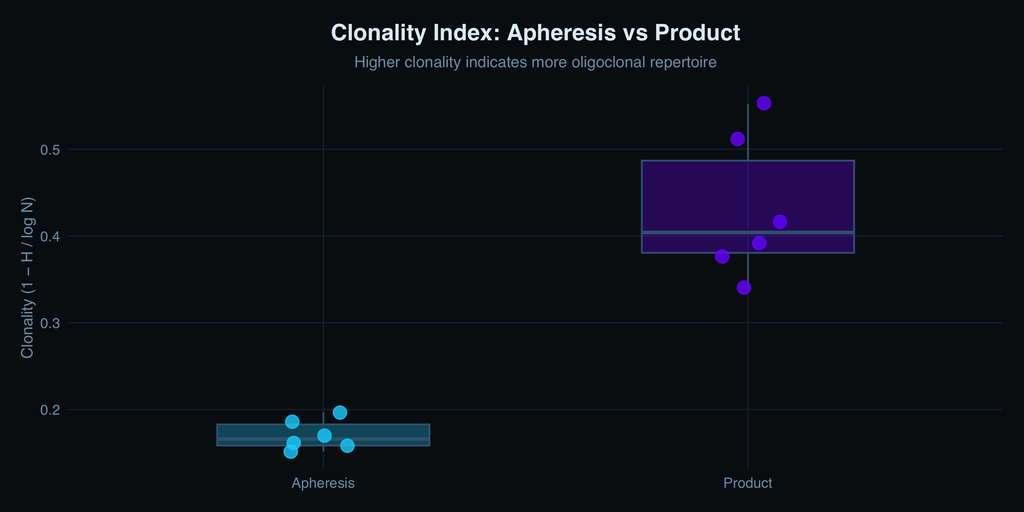

```r
ggplot(diversity_df, aes(x = sample_type, y = clonality, fill = sample_type)) +
  geom_boxplot(alpha = 0.3, outlier.shape = NA, width = 0.5, color = "#3f6380") +
  geom_jitter(aes(color = sample_type), width = 0.08, size = 4, alpha = 0.8) +
  scale_fill_manual(values = c("Apheresis" = "#00d4ff", "Product" = "#7b2fff")) +
  scale_color_manual(values = c("Apheresis" = "#00d4ff", "Product" = "#7b2fff")) +
  labs(y = "Clonality (1 − H / log N)", x = NULL,
       title = "Clonality Index: Apheresis vs Product",
       subtitle = "Higher clonality indicates more oligoclonal repertoire") +
  theme(legend.position = "none")
```

> **Finding:** Product samples exhibit **2–3× higher clonality** than matched Apheresis samples, confirming that manufacturing drives substantial clonal selection and expansion.

## Repertoire Richness & D50

**Richness** measures the total number of unique clonotypes. **D50** measures the minimum number of clonotypes comprising the top 50% of all reads — a low D50 indicates a highly skewed repertoire.

```r
diversity_df %>%
  select(patient_id, sample_type, n_clonotypes, d50) %>%
  pivot_wider(names_from = sample_type, values_from = c(n_clonotypes, d50)) %>%
  mutate(fold_change = round(n_clonotypes_Apheresis / n_clonotypes_Product, 1)) %>%
  knitr::kable(
    caption = "Richness and D50 comparison",
    format.args = list(big.mark = ",")
  )
```

Richness and D50 comparison

| patient_id | n_clonotypes_Apheresis | n_clonotypes_Product | d50_Apheresis | d50_Product | fold_change |
| --- | --- | --- | --- | --- | --- |
| PT-001 | 13,238 | 2,029 | 1,816 | 3 | 6.5 |
| PT-002 | 14,132 | 940 | 2,046 | 1 | 15.0 |
| PT-003 | 11,658 | 1,123 | 1,379 | 2 | 10.4 |
| PT-004 | 12,786 | 2,474 | 1,639 | 5 | 5.2 |
| PT-005 | 9,771 | 1,913 | 858 | 5 | 5.1 |
| PT-006 | 8,676 | 2,853 | 614 | 11 | 3.0 |

## Diversity by Clinical Response

We stratify the diversity metrics by clinical response to explore whether the **degree of clonal focusing** in the Product is associated with treatment outcome.

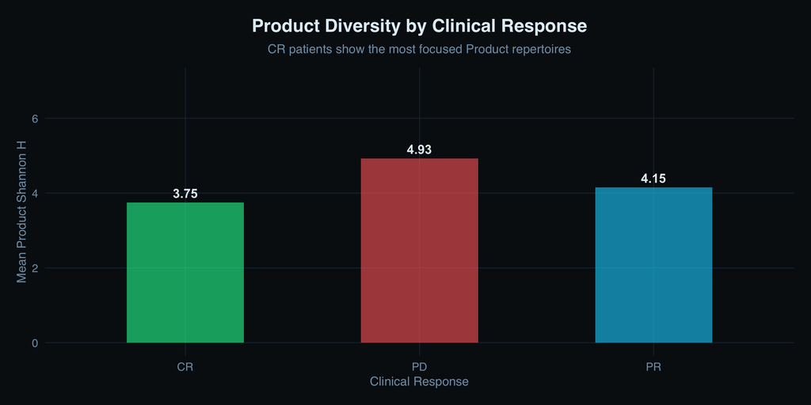

```r
diversity_df %>%
  filter(sample_type == "Product") %>%
  group_by(clinical_response) %>%
  summarise(mean_shannon = mean(shannon_entropy), .groups = "drop") %>%
  ggplot(aes(x = clinical_response, y = mean_shannon, fill = clinical_response)) +
  geom_col(alpha = 0.6, width = 0.5) +
  geom_text(aes(label = round(mean_shannon, 2)), vjust = -0.5,
            color = "#e0eef5", size = 4, fontface = "bold") +
  scale_fill_manual(values = c("CR" = "#00ff9d", "PR" = "#00d4ff", "PD" = "#ff6b6b")) +
  labs(y = "Mean Product Shannon H", x = "Clinical Response",
       title = "Product Diversity by Clinical Response",
       subtitle = "CR patients show the most focused Product repertoires") +
  theme(legend.position = "none") +
  ylim(0, 7)
```

> **Finding:** Complete responders (CR) show the **most focused Product repertoires** (lowest Shannon H, highest clonality), suggesting that effective clonal selection during manufacturing may be associated with clinical benefit. Progressive disease patients retain relatively higher Product diversity.